# Phân tích các yếu tố ảnh hưởng đến xếp hạng của ứng dụng trên google play store

Nguyễn Ngọc Hòa & Lê Đình Khang & Võ Thị Thanh Ngân

24/01/2021

```r
library(tidyverse)
library(ggplot2)
setwd("~")
```

## A. Giới thiệu

Dữ liệu ứng dụng trên Cửa hàng Play (Google Play) có tiềm năng to lớn để thúc đẩy các doanh nghiệp sản xuất ứng dụng thành công. Thông tin chi tiết hữu ích có thể được rút ra để các nhà phát triển như chúng ta làm việc và nắm bắt thị trường Android! Chính vì thế, với project này, chúng ta sẽ cùng thực hiện một số phân tích thống kê về dữ liệu thu thập được từ CH Play để tìm ra các xu hướng và mẫu liên quan đến thị trường nhằm mục đích giúp các nhà phát triển định hướng cũng như tìm ra con đường đúng đăn để phát triển các ứng dụng Android.

## B. Dữ liệu

Tập dữ liệu đầu vào được tìm thấy trên Kaggle và thông tin được thu thập thông qua việc tìm kiếm trên web khoảng 10.000 ứng dụng Cửa hàng Play. Vì Google Play sử dụng các kỹ thuật hiện đại như tải trang động bằng JQuery, điều này khiến việc tìm kiếm khó khăn hơn. Mỗi ứng dụng có các giá trị cho danh mục, xếp hạng, kích thước, lượt cài đặt và các thông số kỹ thuật ứng dụng khác. Mặc dù Google Play cũng hoạt động như một cửa hàng phương tiện kỹ thuật số,nhưng trong phạm vi bài phân tích này chúng ta chỉ quan tâm đến ứng dụng Android vì thế dữ liệu chỉ bao gồm các ứng dụng di động.

```r
ggAppData <- read.csv("./Data/googleplaystore.csv")
str(ggAppData)
```

```
## 'data.frame':    10841 obs. of  13 variables:
##  $ App           : chr  "Photo Editor & Candy Camera & Grid & ScrapBook" "Coloring book moana" "U Launcher Lite – FREE Live Cool Themes, Hide Apps" "Sketch - Draw & Paint" ...
##  $ Category      : chr  "ART_AND_DESIGN" "ART_AND_DESIGN" "ART_AND_DESIGN" "ART_AND_DESIGN" ...
##  $ Rating        : num  4.1 3.9 4.7 4.5 4.3 4.4 3.8 4.1 4.4 4.7 ...
##  $ Reviews       : chr  "159" "967" "87510" "215644" ...
##  $ Size          : chr  "19M" "14M" "8.7M" "25M" ...
##  $ Installs      : chr  "10,000+" "500,000+" "5,000,000+" "50,000,000+" ...
##  $ Type          : chr  "Free" "Free" "Free" "Free" ...
##  $ Price         : chr  "0" "0" "0" "0" ...
##  $ Content.Rating: chr  "Everyone" "Everyone" "Everyone" "Teen" ...
##  $ Genres        : chr  "Art & Design" "Art & Design;Pretend Play" "Art & Design" "Art & Design" ...
##  $ Last.Updated  : chr  "January 7, 2018" "January 15, 2018" "August 1, 2018" "June 8, 2018" ...
##  $ Current.Ver   : chr  "1.0.0" "2.0.0" "1.2.4" "Varies with device" ...
##  $ Android.Ver   : chr  "4.0.3 and up" "4.0.3 and up" "4.0.3 and up" "4.2 and up" ...
```

## C. Mô tả các biến trong tập dữ liệu:

Tập dữ liệu gồm 13 biến như sau(Lưu ý tất cả dữ liệu đều được thu thập từ năm 2019):

- App : Tên của ứng dụng
- Category: Danh mục (Loại của ứng dụng)
- Rating: Trung bình xếp hạng của người dùng dành cho ứng dụng (Từ 1 đến 5)
- Reviews: Số lượng đánh giá của người dùng danh cho ứng dụng
- Size: Kích thước của ứng dụng.
- Installs: Số lượng người dùng đã cài đặt ứng dụng.
- Type: Ứng dụng miễn phí hoặc trả tiền.
- Price: Giá của ứng dụng.
- Content Rating: Nhóm tuổi mà ứng dụng nhắm đến
- Genres: Thể loại phụ(Một ứng dụng có thể thuộc nhiều thể loại. Ví dụ: một trò chơi gia đình âm nhạc sẽ thuộc thể loại Âm nhạc, Trò chơi, Gia đình.)
- Last Updated: Lần cuối ứng dụng được cập nhật
- Current Ver: Phiên bản hiện tại của ứng dụng.
- Android Ver: Phiên bản Android thấp nhất mà ứng dụng yêu cầu để cài đặt được ứng dụng.

## D. Câu hỏi phân tích:

### 1. Danh mục(Loại) ứng dụng cửa hàng Google Play nào có xếp hạng cao nhất?

### 2. Liệu xếp hạng của một ứng dụng không bị hạn chế độ tuổi có khác biệt với một ứng dụng bị hạn chế độ tuổi hay không?

### 3. Có sự khác biệt đáng kể về xếp hạng giữa ứng dụng cửa hàng Google Play trả phí hay miễn phí không?

## E. Hiểu vấn đề

### I.Xem lướt qua dữ liệu

#### 1.Các danh mục ứng dụng có khác biệt về xếp hạng hay không? Để trả lời câu hỏi này, ta xem qua danh mục ART AND DESIGN(ứng dụng đồ họa và thiết kế) và danh mục EDUCATION(ứng dụng giáo dục) xem 2 loại này có khác biệt rõ ràng về xếp hạng hay không

```r
ggAppData <- read.csv("./Data/googleplaystore.csv")
head(ggAppData[ggAppData$Category=='ART_AND_DESIGN',c(2,3)],10)
```

```
##          Category Rating
## 1  ART_AND_DESIGN    4.1
## 2  ART_AND_DESIGN    3.9
## 3  ART_AND_DESIGN    4.7
## 4  ART_AND_DESIGN    4.5
## 5  ART_AND_DESIGN    4.3
## 6  ART_AND_DESIGN    4.4
## 7  ART_AND_DESIGN    3.8
## 8  ART_AND_DESIGN    4.1
## 9  ART_AND_DESIGN    4.4
## 10 ART_AND_DESIGN    4.7
```

```r
head(ggAppData[ggAppData$Category=='EDUCATION',c(2,3)],10)
```

```
##      Category Rating
## 700 EDUCATION    4.7
## 701 EDUCATION    4.6
## 702 EDUCATION    4.7
## 703 EDUCATION    4.6
## 704 EDUCATION    4.7
## 705 EDUCATION    NaN
## 706 EDUCATION    4.5
## 707 EDUCATION    4.7
## 708 EDUCATION    4.8
## 709 EDUCATION    4.6
```

```r
head(ggAppData[,c(3,9)],15)
```

```
##    Rating Content.Rating
## 1     4.1       Everyone
## 2     3.9       Everyone
## 3     4.7       Everyone
## 4     4.5           Teen
## 5     4.3       Everyone
## 6     4.4       Everyone
## 7     3.8       Everyone
## 8     4.1       Everyone
## 9     4.4       Everyone
## 10    4.7       Everyone
## 11    4.4       Everyone
## 12    4.4       Everyone
## 13    4.2           Teen
## 14    4.6       Everyone
## 15    4.4       Everyone
```

#### 3. 10 ứng dụng trả phí đầu tiên có xếp hạng như thế nào so với 10 ứng dụng miễn phí đầu tiên?

```r
head(ggAppData[ggAppData$Type=='Paid',c(7,3)],10)
```

```
##     Type Rating
## 235 Paid    4.7
## 236 Paid    4.8
## 291 Paid    4.7
## 292 Paid    4.8
## 428 Paid    4.0
## 477 Paid    4.2
## 478 Paid    2.6
## 479 Paid    NaN
## 480 Paid    NaN
## 481 Paid    NaN
```

```r
head(ggAppData[ggAppData$Type=='Free',c(7,3)],10)
```

```
##    Type Rating
## 1  Free    4.1
## 2  Free    3.9
## 3  Free    4.7
## 4  Free    4.5
## 5  Free    4.3
## 6  Free    4.4
## 7  Free    3.8
## 8  Free    4.1
## 9  Free    4.4
## 10 Free    4.7
```

- Xếp hạng của các ứng dụng có vẻ phân tán và không thể hiện sự khác biệt rõ ràng giữa 2 loại này.

### II. Thiết kế nghiên cứu

- Xét về mặt đặc tính của nghiên cứu thì nghiên cứu này là nghiên cứu quan sát (observational study) vì chúng ta chỉ quan sát và ghi nhận thực trạng đặc điểm/đặc tính và sự kiện diễn ra trong nghiên cứu mà không có tác động đến đối tượng nghiên cứu.
- Vì chúng ta không có bất kỳ mẫu nào để so sánh nên nghiên cứu quan sát trên chỉ đơn giản là một nghiên cứu mô tả.
- Như đã đề cập ở phần trên dữ liệu được thu thập bằng cách tìm kiếm trên các trang web và vì vấn đề kỹ thuật nên việc này khá khó khăn. Vì thế các phần tử trong tập dữ liệu này hoàn toàn là ngẫu nhiên và xác suất được chọn của các ứng dụng là như nhau. chính vì vậy, cách lấy mẫu ở đây là chọn mẫu theo xác suất và phương pháp chọn mẫu là phương pháp chọn mẫu ngẫu nhiên đơn giản(Simple random sampling)

## F. Suy ngẫm về câu hỏi

### Trước khi chúng ta bắt đầu phân tích dữ liệu bằng cách trực quan hóa và kiểm định thống kê thì chúng ta sẽ trả lời một cách chủ quan các câu hỏi đã đề ra:

- Đầu tiên, như chúng ta đã biết, hiện nay các ứng dụng liên quan đến giáo dục,giải trí đang rất thịnh hành, chính vì thế theo ý kiến chủ quan thì ta có thể dự đoán rằng các ứng dụng này thường sẽ có rating(xếp hạng người dùng) cao hơn các ứng dụng thuộc các lĩnh vực còn lại.
- Dĩ nhiên trong thực tế, bị giới hạn hoặc buộc phải xác thực độ tuổi khi sử dụng một ứng dụng là điều khá bất tiện, chính vì thế điều này sẽ ảnh hưởng đến rating của người dùng dành cho ứng dụng. Vì thế có lẽ các ứng dụng không giới hạn độ tuổi thường sẽ có rating cao hơn.
- Cuối cùng, một ứng dụng phải trả tiền thì nó sẽ đem lại những trải nghiệm tốt hơn cũng như luôn có trách nhiệm với người dùng của mình hơn, vì thế nên độ hài lòng của khách hàng có vẻ như sẽ cao hơn các ứng dụng miễn phí.

## G. Phân tích dữ liệu

Đầu tiên, chúng ta xóa các dòng bị thiếu hoặc NaN vì chúng chiếm số lượng khá nhỏ so với tập dữ liệu của chúng ta.

```r
googlePS <-as.data.frame(ggAppData)
str(googlePS)
```

```
## 'data.frame':    10841 obs. of  13 variables:
##  $ App           : chr  "Photo Editor & Candy Camera & Grid & ScrapBook" "Coloring book moana" "U Launcher Lite – FREE Live Cool Themes, Hide Apps" "Sketch - Draw & Paint" ...
##  $ Category      : chr  "ART_AND_DESIGN" "ART_AND_DESIGN" "ART_AND_DESIGN" "ART_AND_DESIGN" ...
##  $ Rating        : num  4.1 3.9 4.7 4.5 4.3 4.4 3.8 4.1 4.4 4.7 ...
##  $ Reviews       : chr  "159" "967" "87510" "215644" ...
##  $ Size          : chr  "19M" "14M" "8.7M" "25M" ...
##  $ Installs      : chr  "10,000+" "500,000+" "5,000,000+" "50,000,000+" ...
##  $ Type          : chr  "Free" "Free" "Free" "Free" ...
##  $ Price         : chr  "0" "0" "0" "0" ...
##  $ Content.Rating: chr  "Everyone" "Everyone" "Everyone" "Teen" ...
##  $ Genres        : chr  "Art & Design" "Art & Design;Pretend Play" "Art & Design" "Art & Design" ...
##  $ Last.Updated  : chr  "January 7, 2018" "January 15, 2018" "August 1, 2018" "June 8, 2018" ...
##  $ Current.Ver   : chr  "1.0.0" "2.0.0" "1.2.4" "Varies with device" ...
##  $ Android.Ver   : chr  "4.0.3 and up" "4.0.3 and up" "4.0.3 and up" "4.2 and up" ...
```

```r
googlePlay <- googlePS[complete.cases(googlePS),]
#Kiểm tra và xóa giá trị nhập lỗi trong dataset
googlePlay<-googlePlay[googlePlay$Rating<=5,]
```

Trong phạm vi của bài phân tích này, chúng ta sử dụng 3 loại biểu đồ, side by side boxplots để so sánh center, spread và outliers của các nhóm; histogram để mô tả phân bố của từng mẫu và QQplot để so sánh phân phối xác suất của mẫu với phân phối chuẩn.

### Câu hỏi 1:Danh mục(Loại) ứng dụng cửa hàng Google Play nào có xếp hạng cao nhất?

Trong phạm vi của bài phân tích này, ta chỉ quan tâm đến một số danh mục phổ biến và nổi bật trong thực tế như: GAME, BUSINESS, EDUCATION, ENTERTAINMENT, LIFESTYLE, DATING

```r
q1<-googlePlay[googlePlay$Category==c('GAME','BUSINESS','EDUCATION','ENTERTAINMENT','LIFESTYLE','DATING'),]
```

#### 1. Xác định các biến có liên quan

- Biến giải thích: Category, loại categorical
- Biến phản hồi: Rating, loại quantitative

#### 2. Phân tích thăm dò (Exploratory Analysis)

- Vẽ biểu đồ side by side boxplots

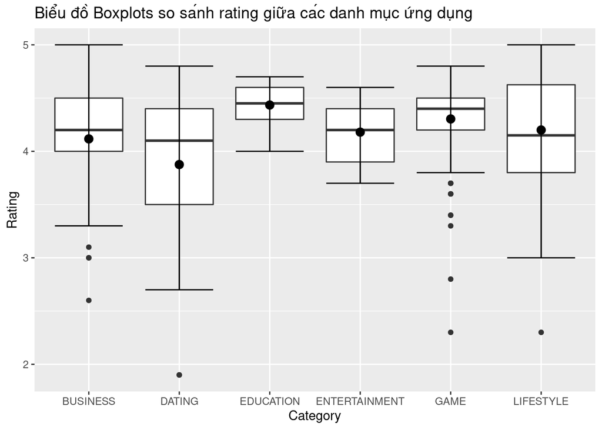

```r
## Side by side boxplot
ggplot(data = q1, aes(x = Category, y = Rating),ylim=c(0,5)) +
  geom_boxplot() +
  stat_boxplot(geom = "errorbar") +
  stat_summary(fun.y = mean, col = "black", geom = "point", size = 3) +
  ggtitle("Biểu đồ Boxplots so sánh rating giữa các danh mục ứng dụng")
```

- Tóm tắt Five-numbers summary:

```r
tapply(q1$Rating, q1$Category, summary)
```

```
## $BUSINESS
##    Min. 1st Qu.  Median    Mean 3rd Qu.    Max.
##   2.600   4.000   4.200   4.117   4.500   5.000
##
## $DATING
##    Min. 1st Qu.  Median    Mean 3rd Qu.    Max.
##   1.900   3.500   4.100   3.876   4.400   4.800
##
## $EDUCATION
##    Min. 1st Qu.  Median    Mean 3rd Qu.    Max.
##   4.000   4.300   4.450   4.435   4.600   4.700
##
## $ENTERTAINMENT
##    Min. 1st Qu.  Median    Mean 3rd Qu.    Max.
##    3.70    3.90    4.20    4.18    4.40    4.60
##
## $GAME
##    Min. 1st Qu.  Median    Mean 3rd Qu.    Max.
##   2.300   4.200   4.400   4.304   4.500   4.800
##
## $LIFESTYLE
##    Min. 1st Qu.  Median    Mean 3rd Qu.    Max.
##   2.300   3.800   4.150   4.200   4.625   5.000
```

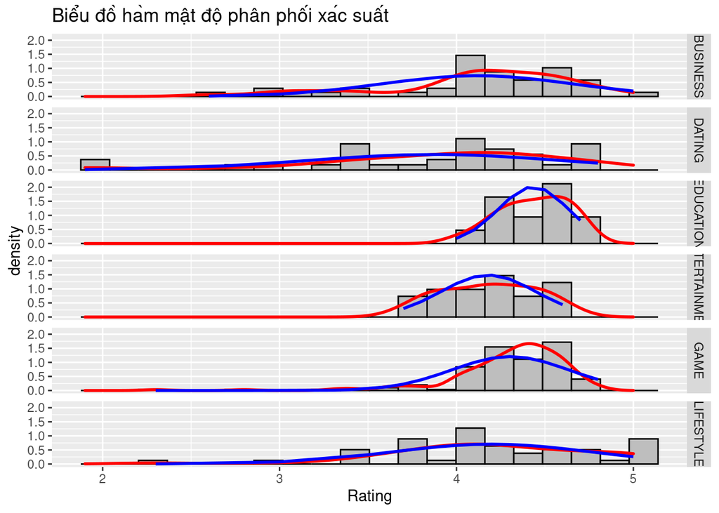

```r
# Biểu đồ Histogram
xbar <- tapply(q1$Rating, q1$Category, mean)
s <- tapply(q1$Rating, q1$Category, sd)
q1$normal.density <- apply(q1, 1, function(x){
  dnorm(as.numeric(x["Rating"]),
        xbar[x["Category"]], s[x["Category"]])})
ggplot(q1, aes(x = Rating)) +
  geom_histogram(aes(y = ..density..),
                 bins = 20,
                 fill = "grey", col = "black") +
  facet_grid(Category ~ .) +
  geom_density(col = "red", lwd = 1) +
  geom_line(aes(y = normal.density), col = "blue", lwd = 1) +
  ggtitle("Biểu đồ hàm mật độ phân phối xác suất")
```

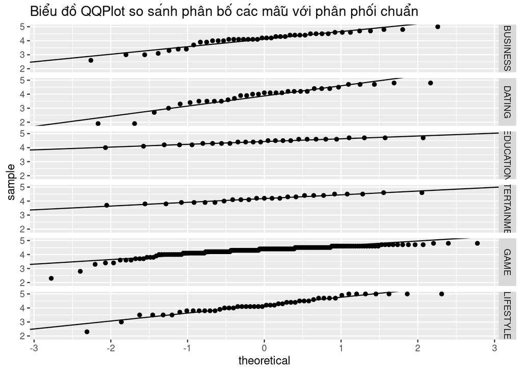

```r
# Biểu đồ QQ plot
q1$intercept <- apply(q1, 1, function(x){xbar[x["Category"]]})
q1$slope <- apply(q1, 1, function(x){s[x["Category"]]})
ggplot(q1, aes(sample = Rating)) +
  stat_qq() +
  facet_grid(Category ~ .) +
  geom_abline(data = q1, aes(intercept = intercept, slope = slope)) +
  ggtitle("Biểu đồ QQPlot so sánh phân bố các mẫu với phân phối chuẩn")
```

- Trên biểu đồ QQplot ta thấy sự liên quan giữa các giá trị mong đợi(truc hoành) và các giá trị quan sát được(trục tung) của các mẫu đều có vẻ như nằm trên đường thẳng chéo, vì thế nên các mẫu này đều khá gần với phân phối chuẩn. Điều này giúp chúng ta có thể yên tâm hơn khi sử dụng định lý giới hạn trung tâm để thực hiện các kiểm định thống kê.

#### 3. Suy diễn

- Suy diễn thống kê cho thống kê hiện tại thuộc loại so sánh nhiều hơn 2 population mean.
- Kiểm định thống kê phù hợp cho câu hỏi này là ANOVA F-test
- Xác định các giả thuyết
  - Null hypothesis: $H_0:$ Không có sự khác biệt về Rating giữa các danh mục ứng dụng khác nhau
  - Alternative hypothesis: $H_A:$Có sự khác biệt về Rating giữa các danh mục ứng dụng khác nhau

```r
# ANOVA test
fit <- aov(Rating ~ Category, data = q1)
summary(fit)
```

```
##              Df Sum Sq Mean Sq F value   Pr(>F)
## Category      5   6.87  1.3734   7.252 1.77e-06 ***
## Residuals   350  66.29  0.1894
## ---
## Signif. codes:  0 '***' 0.001 '**' 0.01 '*' 0.05 '.' 0.1 ' ' 1
```

```r
TukeyHSD(fit, conf.level = 0.95)
```

```
##   Tukey multiple comparisons of means
##     95% family-wise confidence level
##
## Fit: aov(formula = Rating ~ Category, data = q1)
##
## $Category
##                                diff          lwr        upr     p adj
## DATING-BUSINESS         -0.24090909 -0.531000866 0.04918268 0.1662106
## EDUCATION-BUSINESS       0.31794872  0.006755921 0.62914151 0.0420021
## ENTERTAINMENT-BUSINESS   0.06333333 -0.251680155 0.37834682 0.9925324
## GAME-BUSINESS            0.18717949 -0.026297010 0.40065598 0.1232011
## LIFESTYLE-BUSINESS       0.08333333 -0.180155606 0.34682227 0.9447610
## EDUCATION-DATING         0.55885781  0.231841991 0.88587363 0.0000219
## ENTERTAINMENT-DATING     0.30424242 -0.026411302 0.63489615 0.0912889
## GAME-DATING              0.42808858  0.192142391 0.66403477 0.0000051
## LIFESTYLE-DATING         0.32424242  0.042240989 0.60624386 0.0137452
## ENTERTAINMENT-EDUCATION -0.25461538 -0.603928432 0.09469766 0.2955536
## GAME-EDUCATION          -0.13076923 -0.392223476 0.13068501 0.7066957
## LIFESTYLE-EDUCATION     -0.23461538 -0.538280543 0.06904977 0.2339009
## GAME-ENTERTAINMENT       0.12384615 -0.142144191 0.38983650 0.7657761
## LIFESTYLE-ENTERTAINMENT  0.02000000 -0.287579372 0.32757937 0.9999688
## LIFESTYLE-GAME          -0.10384615 -0.306191865 0.09849956 0.6832541
```

- Dựa vào kết quả trên, ANOVA F-test chỉ ra rằng có bằng chứng thống kê đáng kể để kết luận rằng rating trung bình thực sự giữa tất cả các danh mục là không bằng nhau.
  - p-value = 1.77e-6
  - Vì $p$-value nhỏ hơn mức ý nghĩa $\alpha = 0.05$ nên ta bác bỏ $H_0$.
  - Dựa vào bảng HSD ta có thể thấy được các cặp mẫu có p-value nhỏ hơn 0.05 là có sự khác biệt về rating theo mặt thống kê .

### Câu hỏi 2: Liệu xếp hạng của một ứng dụng không bị hạn chế độ tuổi có khác biệt với một ứng dụng bị hạn chế độ tuổi hay không?

Đầu tiên ta có thể hiểu không bị giới hạn độ tuổi tức là hướng đến tât cả mọi người:

```r
googlePlay$Content.Rating<-ifelse(googlePlay$Content.Rating=='Everyone','Non-restricted','Restricted')
```

#### 1. Xác định các biến có liên quan

- Biến giải thích: Content.Rating, loại categorical
- Biến phản hồi: Rating, loại quantitative

#### 2. Phân tích thăm dò (Exploratory Analysis)

- Vẽ biểu đồ side by side boxplot

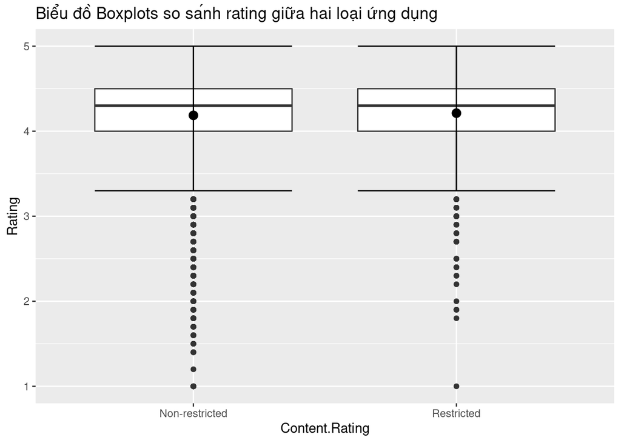

```r
# Side by side boxplot of data
ggplot(data = googlePlay, aes(x = Content.Rating, y = Rating)) +
  geom_boxplot() +
  stat_boxplot(geom = "errorbar") +
  stat_summary(fun.y = mean, col = "black", geom = "point", size = 3) +
  ggtitle("Biểu đồ Boxplots so sánh rating giữa hai loại ứng dụng")
```

- Tóm tắt Five-numbers summary:

```r
tapply(googlePlay$Rating, googlePlay$Content.Rating, summary)
```

```
## $`Non-restricted`
##    Min. 1st Qu.  Median    Mean 3rd Qu.    Max.
##   1.000   4.000   4.300   4.186   4.500   5.000
##
## $Restricted
##    Min. 1st Qu.  Median    Mean 3rd Qu.    Max.
##   1.000   4.000   4.300   4.212   4.500   5.000
```

- Center: Trung vị rating của các ứng dụng giới hạn độ tuổi và không giới hạn độ tuổi là như nhau
- Spread: Rating của hai mẫu này có range bằng nhau
- Outliers: Có vẻ như rating của 2 loại ứng dụng này tương đối phân tán khi có khá nhiều giá trị ngoại biên
- Vẽ biểu đồ histogram:

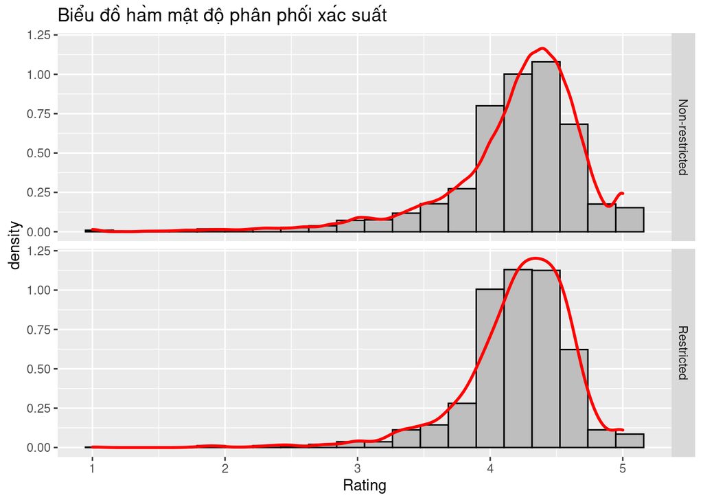

```r
# Histogram of data
xbar <- tapply(googlePlay$Rating, googlePlay$Content.Rating, mean)
s <- tapply(googlePlay$Rating, googlePlay$Content.Rating, sd)
googlePlay$normal.density <- apply(googlePlay, 1, function(x){
  dnorm(as.numeric(x["Rating"]),
        xbar[x["Content Rating"]], s[x["Content Rating"]])})
ggplot(googlePlay, aes(x = Rating)) +
  geom_histogram(aes(y = ..density..),
                 bins = 20,
                 fill = "grey", col = "black") +
  facet_grid(Content.Rating ~ .) +
  geom_density(col = "red", lwd = 1) +
  geom_line(aes(y = normal.density), col = "blue", lwd = 1) +
  ggtitle("Biểu đồ hàm mật độ phân phối xác suất")
```

- Vẽ biểu đồ QQplot

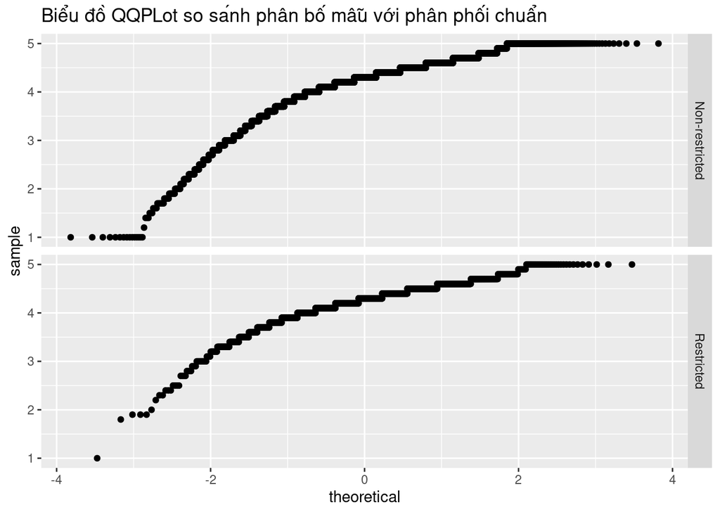

```r
# QQ Plot of data
googlePlay$intercept <- apply(googlePlay, 1, function(x){xbar[x["Content Rating"]]})
googlePlay$slope <- apply(googlePlay, 1, function(x){s[x["Content Rating"]]})
ggplot(googlePlay, aes(sample = Rating)) +
  stat_qq() +
  facet_grid(Content.Rating ~ .) +
  geom_abline(data = googlePlay, aes(intercept = intercept, slope = slope)) +
  ggtitle("Biểu đồ QQPLot so sánh phân bố mẫu với phân phối chuẩn")
```

#### 3. Suy diễn

- Suy diễn thống kê cho thống kê hiện tại thuộc loại so sánh hai population mean
- Kiểm định thống kê phù hợp cho câu hỏi này là two sample t-test for two means ($\mu_1, \mu_2$)
- Xác định các giả thuyết
  - Null hypothesis: $H_0: \mu_1 - \mu_2 = 0$
  - Alternative hypothesis: $H_A: \mu_1 - \mu_2 \ne 0$
- **Tính test statistic**

```r
mu2 = mean(googlePlay[googlePlay$Content.Rating=='Restricted',3])
mu1 = mean(googlePlay[googlePlay$Content.Rating=='Non-restricted',3])
n2 = length(googlePlay[googlePlay$Content.Rating=='Restricted',3])
n1 = length(googlePlay[googlePlay$Content.Rating=='Non-restricted',3])
s2 = sd(googlePlay[googlePlay$Content.Rating=='Restricted',3])
s1 = sd(googlePlay[googlePlay$Content.Rating=='Non-restricted',3])
se = sqrt(s1^2/n1 + s2^2/n2)
t = (mu1 - mu2)/se
```

- **Tính p-value**

```r
v = (s2^2/n2 + s1^2/n1)^2/((s1^2/n1)^2/(n1-1) + (s2^2/n2)^2/(n2-1))
p_value = 2*pt(q = t, df = v)
p_value
```

```
## [1] 0.02281833
```

- Kiểm tra lại bằng hàm `t.test` trong R

```r
# t-Test
t.test(googlePlay$Rating ~ googlePlay$Content.Rating, mu = 0, conf.level = 0.95,
       paired = FALSE, alternative = "two.sided", var.equal = FALSE)
```

```
##
##  Welch Two Sample t-test
##
## data:  googlePlay$Rating by googlePlay$Content.Rating
## t = -2.2774, df = 3793.9, p-value = 0.02282
## alternative hypothesis: true difference in means is not equal to 0
## 95 percent confidence interval:
##  -0.048210044 -0.003603837
## sample estimates:
## mean in group Non-restricted     mean in group Restricted
##                     4.186375                     4.212282
```

```r
#Kiểm tra kỳ vọng của chúng ta:
t.test(googlePlay$Rating ~ googlePlay$Content.Rating, mu = 0, conf.level = 0.95,
       paired = FALSE, alternative = "greater", var.equal = FALSE)
```

```
##
##  Welch Two Sample t-test
##
## data:  googlePlay$Rating by googlePlay$Content.Rating
## t = -2.2774, df = 3793.9, p-value = 0.9886
## alternative hypothesis: true difference in means is greater than 0
## 95 percent confidence interval:
##  -0.04462289         Inf
## sample estimates:
## mean in group Non-restricted     mean in group Restricted
##                     4.186375                     4.212282
```

- Dựa vào kết quả trên, two sample t-test chỉ ra rằng có bằng chứng thống kê đáng kể để kết luận rằng Rating của những ứng dụng bị giới hạn độ tuổi và không bị giới hạn là thực sự khác nhau.
  - p-value = 0.0228
  - Vì $p$-value nhỏ hơn mức ý nghĩa $\alpha = 0.05$ nên ta bác bỏ $H_0$.

### Câu hỏi 3:Có sự khác biệt đáng kể về xếp hạng giữa ứng dụng cửa hàng Google Play trả phí hay miễn phí không?

#### 1. Xác định các biến có liên quan

- Biến giải thích: Type, loại categorical
- Biến phản hồi: Rating, loại quantitative

#### 2. Phân tích thăm dò (Exploratory Analysis)

- Vẽ biểu đồ side by side boxplots

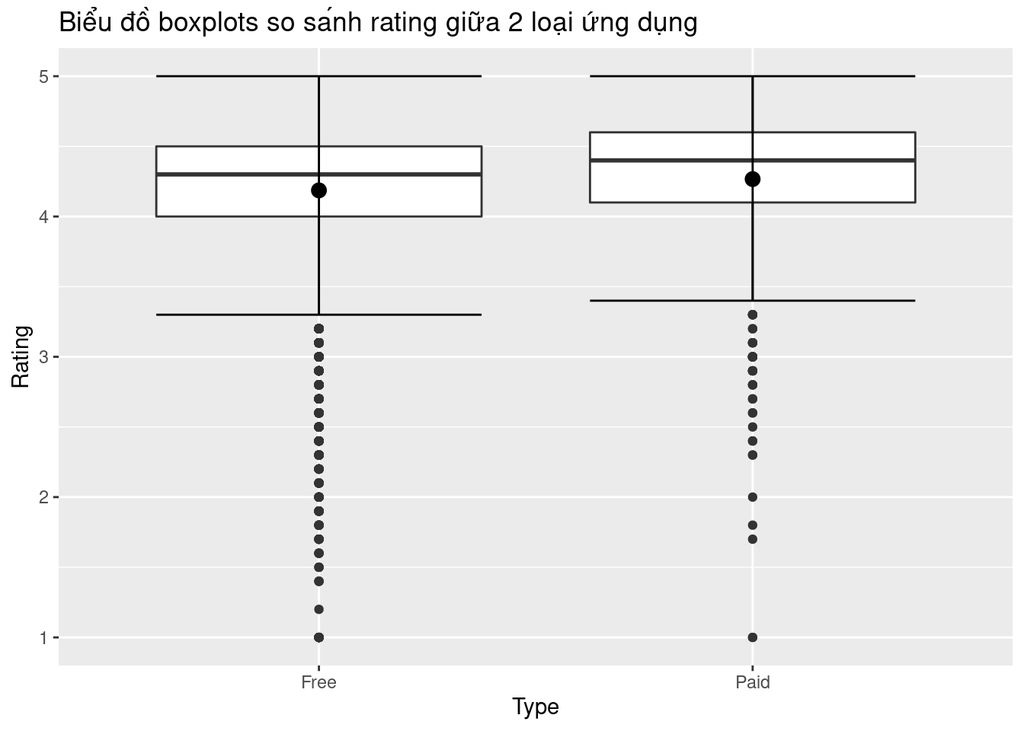

```r
# Side by side boxplot of data
ggplot(data = googlePlay, aes(x = Type, y = Rating)) +
  geom_boxplot() +
  stat_boxplot(geom = "errorbar") +
  stat_summary(fun.y = mean, col = "black", geom = "point", size = 3) +
  ggtitle("Biểu đồ boxplots so sánh rating giữa 2 loại ứng dụng")
```

- Tóm tắt Five-numbers summary:

```r
tapply(googlePlay$Rating, googlePlay$Type, summary)
```

```
## $Free
##    Min. 1st Qu.  Median    Mean 3rd Qu.    Max.
##   1.000   4.000   4.300   4.186   4.500   5.000
##
## $Paid
##    Min. 1st Qu.  Median    Mean 3rd Qu.    Max.
##   1.000   4.100   4.400   4.267   4.600   5.000
```

- Center: Trung vị rating của các ứng dụng trả tiền là cao hơn nhưng không đáng kể.
- Spread: Rating của hai mẫu này có range bằng nhau.
- Outliers: Có vẻ như rating của 2 loại ứng dụng này tương đối phân tán khi có khá nhiều giá trị ngoại biên
- Vẽ biểu đồ histogram

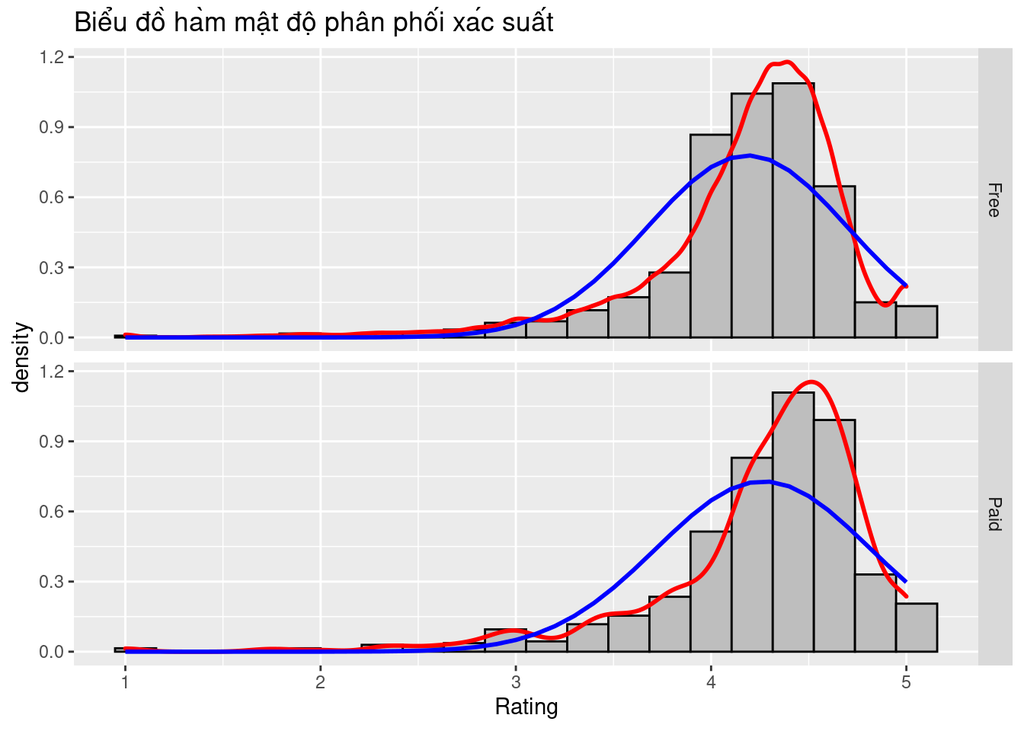

```r
# Histogram of data
xbar <- tapply(googlePlay$Rating, googlePlay$Type, mean)
s <- tapply(googlePlay$Rating, googlePlay$Type, sd)
googlePlay$normal.density <- apply(googlePlay, 1, function(x){
  dnorm(as.numeric(x["Rating"]),
        xbar[x["Type"]], s[x["Type"]])})
ggplot(googlePlay, aes(x = Rating)) +
  geom_histogram(aes(y = ..density..),
                 # bins = sqrt(nrow(bike)) + 2,
                 bins = 20,
                 fill = "grey", col = "black") +
  facet_grid(Type ~ .) +
  geom_density(col = "red", lwd = 1) +
  geom_line(aes(y = normal.density), col = "blue", lwd = 1) +
  ggtitle("Biểu đồ hàm mật độ phân phối xác suất")
```

- Vẽ biểu đồ QQPlot

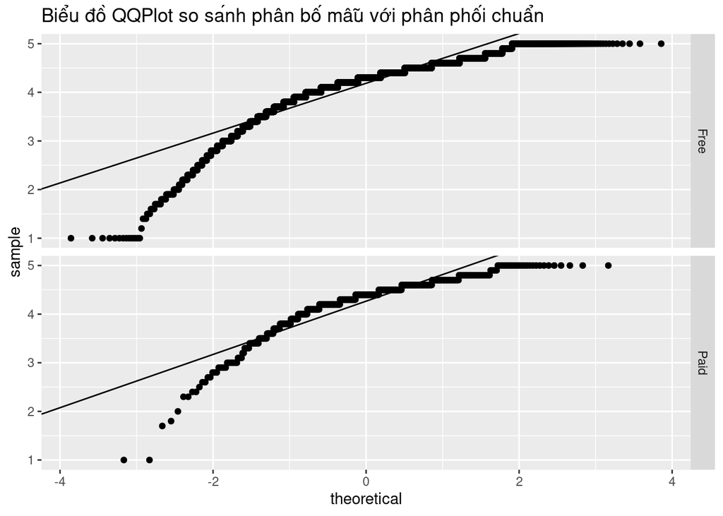

```r
# QQ Plot of data
googlePlay$intercept <- apply(googlePlay, 1, function(x){xbar[x["Type"]]})
googlePlay$slope <- apply(googlePlay, 1, function(x){s[x["Type"]]})
ggplot(googlePlay, aes(sample = Rating)) +
  stat_qq() +
  facet_grid(Type ~ .) +
  geom_abline(data = googlePlay, aes(intercept = intercept, slope = slope)) +
  ggtitle("Biểu đồ QQPlot so sánh phân bố mẫu với phân phối chuẩn")
```

- Ngược lại với 2 phân tích ở trên, ở đây ta thấy hình dạng của histogram không khớp với phân phối chuẩn, mối quan hệ giữa giá trị quan sát và giá trị kỳ vọng cũng không nằm trên đường chéo trong qqplot, việc ta xấp xỉ phân bố mẫu về phân phối chuẩn có thể sẽ bị lệch tuy nhiên cỡ mẫu mà chúng ta sử dụng là khá lớn nên chúng ta vẫn có thể sử dụng định lý giới hạn trung tâm.

#### 3. Suy diễn

- Suy diễn thống kê cho thống kê hiện tại thuộc loại so sánh hai population mean
- Kiểm định thống kê phù hợp cho câu hỏi này là two sample t-test for two means ($\mu_1, \mu_2$)
- Xác định các giả thuyết
  - Null hypothesis: $H_0: \mu_1 - \mu_2 = 0$
  - Alternative hypothesis: $H_A: \mu_1 - \mu_2 \ne 0$
- **Tính test statistic**

```r
mu1 = mean(googlePlay[googlePlay$Type=='Free',3])
mu2 = mean(googlePlay[googlePlay$Type=='Paid',3])
n1 = length(googlePlay[googlePlay$Type=='Free',3])
n2 = length(googlePlay[googlePlay$Type=='Paid',3])
s1 = sd(googlePlay[googlePlay$Type=='Free',3])
s2 = sd(googlePlay[googlePlay$Type=='Paid',3])
se = sqrt(s1^2/n1 + s2^2/n2)
t = (mu1 - mu2)/se
```

- **Tính p-value**

```r
v = (s2^2/n2 + s1^2/n1)^2/((s1^2/n1)^2/(n1-1) + (s2^2/n2)^2/(n2-1))
p_value = 2*pt(q = t, df = v)
p_value
```

```
## [1] 0.0003149307
```

- Kiểm tra lại bằng hàm `t.test` trong R

```r
# t-Test
t.test(googlePlay$Rating ~ googlePlay$Type, mu = 0, conf.level = 0.95,
       paired = FALSE, alternative = "two.sided", var.equal = FALSE)
```

```
##
##  Welch Two Sample t-test
##
## data:  googlePlay$Rating by googlePlay$Type
## t = -3.62, df = 732.45, p-value = 0.0003149
## alternative hypothesis: true difference in means is not equal to 0
## 95 percent confidence interval:
##  -0.12402263 -0.03680257
## sample estimates:
## mean in group Free mean in group Paid
##           4.186203           4.266615
```

```r
# Kiểm định kỳ vọng của chúng ta:
t.test(googlePlay$Rating ~ googlePlay$Type, mu = 0, conf.level = 0.95,
       paired = FALSE, alternative = "less", var.equal = FALSE)
```

```
##
##  Welch Two Sample t-test
##
## data:  googlePlay$Rating by googlePlay$Type
## t = -3.62, df = 732.45, p-value = 0.0001575
## alternative hypothesis: true difference in means is less than 0
## 95 percent confidence interval:
##         -Inf -0.04382812
## sample estimates:
## mean in group Free mean in group Paid
##           4.186203           4.266615
```

- Dựa vào kết quả trên, two sample t-test chỉ ra rằng có bằng chứng thống kê đáng kể để kết luận rằng Rating của những ứng dụng trả phí và không trả phí là thực sự khác nhau
  - p-value = 0.0003
  - Vì $p$-value nhỏ hơn mức ý nghĩa $\alpha = 0.05$ nên ta bác bỏ $H_0$.

#### 4. Kết luận

- Phân tích thăm dò cho thấy sự khác biệt về rating trung bình giữa các ứng dụng miễn phí và có trả tiền cụ thể hơn các ứng dụng trả tiền có rating trung bình cao hơn các ứng dụng miễn phí.
- Kiểm định thống kê cho ra giá trị $p$ rất nhỏ (về cơ bản là 0), cho thấy bằng chứng được cung cấp bởi dữ liệu đủ mạnh để bác bỏ $H_0$ và kết luận rằng có sự khác biệt về Rating giữa các ứng dụng miễn phí và trả tiền. Điều này khá đúng với thực tế khi mà những ứng dụng trả tiền thường có dịch vụ chăm sóc khách hàng tốt hơn.
- Dữ liệu cũng như kết quả của nghiên cứu trên không đưa ra bằng chứng cho việc chúng ta cứ phát hành một ứng dụng miễn phí là rating từ người dùng sẽ thấp hơn so với ứng dụng trả tiền, lý do cũng tương tự như phần này ở những câu hỏi trên. Có thể hiểu sự khác biệt này là vì phần lớn người dùng đánh giá rất cao dịch vụ chăm sóc khách hàng cũng như trải nghiệm của các ứng dụng trả tiền.
- Điều này hoàn toàn trùng khớp với mong đợi của chúng ta và nó cũng thể hiện đúng về mặt thưc tế. Tuy nhiên điều này không hẳn là đúng ở Việt Nam khi các ứng dụng trả tiền rất có ít chỗ đứng và hiển nhiên kéo theo rating cũng khác xa nhau. Mặc dù bạn có thể thử thách bản thân bằng cách phát triển một ứng dụng trả tiền và làm cho nó trở nên trending tuy nhiên lựa chọn an toàn luôn luôn là miễn phí tải về và trả tiền sau.